# Case Study 2

Duy Nguyen

4/10/2022

## Abstract

The CEO and CFO of Frito Lay have provided me with a dataset for the statistics of their employees. They have commissioned me to identify the top factors that lead to employee attrition and evidence provided by analysis to back them up. They are also interested in trends within the dataset, as well as machine learning models to predict attrition and monthly income of their employees.

Things we have found include but are not limited to:

- Numerical and categorical correlations within the dataset
- Top factors that negatively influence attrition
- Top factors that negatively influence monthly income

To close off the analysis, I will provide 2 models that I believe rank amongst the best when predicting employee attitrion and mothnly income that anyone can use for their organizations.

Click here for presentation! https://youtu.be/uuPV2oC6M5s

# Import Data

```r
getwd()
```

```
## [1] "C:/Users/dnguy/Desktop/2 Doing Data Science/Unit 14 & 15 Case Study 2/src"
```

```r
df = read.csv("CaseStudy2-data.csv")
df_no_attrition = read.csv("CaseStudy2CompSet-No-Attrition.csv")
df_no_salary = read.csv("CaseStudy2CompSet-No-Salary.csv")
```

# Missing Values

```r
str(df)
```

```
## 'data.frame':    870 obs. of  36 variables:
##  $ ID                      : int  1 2 3 4 5 6 7 8 9 10 ...
##  $ Age                     : int  32 40 35 32 24 27 41 37 34 34 ...
##  $ Attrition               : chr  "No" "No" "No" "No" ...
##  $ BusinessTravel          : chr  "Travel_Rarely" "Travel_Rarely" "Travel_Frequently" "Travel_Rarely" ...
##  $ DailyRate               : int  117 1308 200 801 567 294 1283 309 1333 653 ...
##  $ Department              : chr  "Sales" "Research & Development" "Research & Development" "Sales" ...
##  $ DistanceFromHome        : int  13 14 18 1 2 10 5 10 10 10 ...
##  $ Education               : int  4 3 2 4 1 2 5 4 4 4 ...
##  $ EducationField          : chr  "Life Sciences" "Medical" "Life Sciences" "Marketing" ...
##  $ EmployeeCount           : int  1 1 1 1 1 1 1 1 1 1 ...
##  $ EmployeeNumber          : int  859 1128 1412 2016 1646 733 1448 1105 1055 1597 ...
##  $ EnvironmentSatisfaction : int  2 3 3 3 1 4 2 4 3 4 ...
##  $ Gender                  : chr  "Male" "Male" "Male" "Female" ...
##  $ HourlyRate              : int  73 44 60 48 32 32 90 88 87 92 ...
```

[output cut: 22 more lines]

```r
table(is.na(df))
```

```
##
## FALSE
## 31320
```

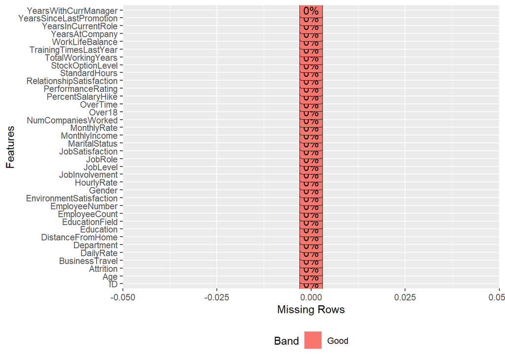

```r
plot_missing(df)
```

# Inspect the Attrition column

```r
prop.table(table(df$Attrition, useNA = "ifany"))
```

```
##
##        No       Yes
## 0.8390805 0.1609195
```

```r
df_Attrition = data.frame(Attrition = table(df$Attrition, useNA = "ifany"))
df_Attrition
```

```
##   Attrition.Var1 Attrition.Freq
## 1             No            730
## 2            Yes            140
```

# Zero Variance

```r
# Identify the names of zero variance columns
zero_var_col_names = nearZeroVar(df, names = TRUE)
zero_var_col_names
```

```
## [1] "EmployeeCount" "Over18"        "StandardHours"
```

```r
# Remove all zero variance columns
df = drop_columns(df, zero_var_col_names)

# Remove "identification" columns that are not useful for analysis
df = df %>% select(-ID, -EmployeeNumber)
```

# Correlation Plot

```r
attritionData <- df
str(attritionData$Attrition)
```

```
##  chr [1:870] "No" "No" "No" "No" "No" "No" "No" "No" "No" "No" "No" "No" ...
```

```r
attritionData$Attrition[attritionData$Attrition == "Yes"] = 0
attritionData$Attrition[attritionData$Attrition == "No"] = 1
attritionData$Attrition_num <- as.numeric(as.character(attritionData$Attrition))

str(select_if(attritionData, is.numeric))
```

```
## 'data.frame':    870 obs. of  24 variables:
##  $ Age                     : int  32 40 35 32 24 27 41 37 34 34 ...
##  $ DailyRate               : int  117 1308 200 801 567 294 1283 309 1333 653 ...
##  $ DistanceFromHome        : int  13 14 18 1 2 10 5 10 10 10 ...
##  $ Education               : int  4 3 2 4 1 2 5 4 4 4 ...
##  $ EnvironmentSatisfaction : int  2 3 3 3 1 4 2 4 3 4 ...
##  $ HourlyRate              : int  73 44 60 48 32 32 90 88 87 92 ...
##  $ JobInvolvement          : int  3 2 3 3 3 3 4 2 3 2 ...
##  $ JobLevel                : int  2 5 3 3 1 3 1 2 1 2 ...
##  $ JobSatisfaction         : int  4 3 4 4 4 1 3 4 3 3 ...
##  $ MonthlyIncome           : int  4403 19626 9362 10422 3760 8793 2127 6694 2220 5063 ...
##  $ MonthlyRate             : int  9250 17544 19944 24032 17218 4809 5561 24223 18410 15332 ...
##  $ NumCompaniesWorked      : int  2 1 2 1 1 1 2 2 1 1 ...
##  $ PercentSalaryHike       : int  11 14 11 19 13 21 12 14 19 14 ...
##  $ PerformanceRating       : int  3 3 3 3 3 4 3 3 3 3 ...
##  $ RelationshipSatisfaction: int  3 1 3 3 3 3 1 3 4 2 ...
##  $ StockOptionLevel        : int  1 0 0 2 0 2 0 3 1 1 ...
##  $ TotalWorkingYears       : int  8 21 10 14 6 9 7 8 1 8 ...
##  $ TrainingTimesLastYear   : int  3 2 2 3 2 4 5 5 2 3 ...
##  $ WorkLifeBalance         : int  2 4 3 3 3 2 2 3 3 2 ...
##  $ YearsAtCompany          : int  5 20 2 14 6 9 4 1 1 8 ...
##  $ YearsInCurrentRole      : int  2 7 2 10 3 7 2 0 1 2 ...
##  $ YearsSinceLastPromotion : int  0 4 2 5 1 1 0 0 0 7 ...
##  $ YearsWithCurrManager    : int  3 9 2 7 3 7 3 0 0 7 ...
##  $ Attrition_num           : num  1 1 1 1 1 1 1 1 1 1 ...
##  - attr(*, ".internal.selfref")=<externalptr>
```

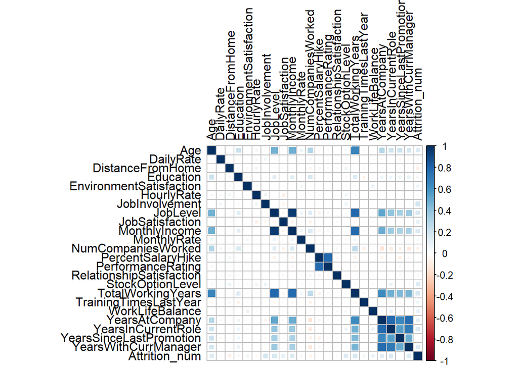

```r
corrplot(cor(select_if(attritionData, is.numeric)), method = "square", tl.col = 'black')
```

```r
model_formula = c("Age", "DailyRate", "Education", "EnvironmentSatisfaction",
                  "JobInvolvement", "JobLevel", "JobSatisfaction", "MonthlyIncome",
                  "MonthlyRate", "RelationshipSatisfaction", "StockOptionLevel",
                  "TotalWorkingYears", "TrainingTimesLastYear", "WorkLifeBalance",
                  "YearsAtCompany", "YearsInCurrentRole", "YearsWithCurrManager")
```

We are giving our model the significant variables seen from the plot above.

# Categorical Variables: Visuallizing Correlations to Attrition

```r
# Convert character variables into factors
df[sapply(df, is.character)] = lapply(df[sapply(df, is.character)], as.factor)

# Numeric variables with a categorical nature are converted into factors
df_numeric_cat_vars = df %>% select(Education, EnvironmentSatisfaction, JobInvolvement,
                                    JobSatisfaction, PerformanceRating,
                                    RelationshipSatisfaction,
                                    WorkLifeBalance) %>% names()
df[df_numeric_cat_vars] = lapply(df[df_numeric_cat_vars], as.factor)

# Sanity check
str(df)
```

```
## 'data.frame':    870 obs. of  31 variables:
##  $ Age                     : int  32 40 35 32 24 27 41 37 34 34 ...
##  $ Attrition               : Factor w/ 2 levels "No","Yes": 1 1 1 1 1 1 1 1 1 1 ...
##  $ BusinessTravel          : Factor w/ 3 levels "Non-Travel","Travel_Frequently",..: 3 3 2 3 2 2 3 3 3 2 ...
##  $ DailyRate               : int  117 1308 200 801 567 294 1283 309 1333 653 ...
##  $ Department              : Factor w/ 3 levels "Human Resources",..: 3 2 2 3 2 2 2 3 3 2 ...
##  $ DistanceFromHome        : int  13 14 18 1 2 10 5 10 10 10 ...
##  $ Education               : Factor w/ 5 levels "1","2","3","4",..: 4 3 2 4 1 2 5 4 4 4 ...
##  $ EducationField          : Factor w/ 6 levels "Human Resources",..: 2 4 2 3 6 2 4 2 2 6 ...
##  $ EnvironmentSatisfaction : Factor w/ 4 levels "1","2","3","4": 2 3 3 3 1 4 2 4 3 4 ...
##  $ Gender                  : Factor w/ 2 levels "Female","Male": 2 2 2 1 1 2 2 1 1 2 ...
##  $ HourlyRate              : int  73 44 60 48 32 32 90 88 87 92 ...
##  $ JobInvolvement          : Factor w/ 4 levels "1","2","3","4": 3 2 3 3 3 3 4 2 3 2 ...
##  $ JobLevel                : int  2 5 3 3 1 3 1 2 1 2 ...
##  $ JobRole                 : Factor w/ 9 levels "Healthcare Representative",..: 8 6 5 8 7 5 7 8 9 1 ...
```

[output cut: 18 more lines]

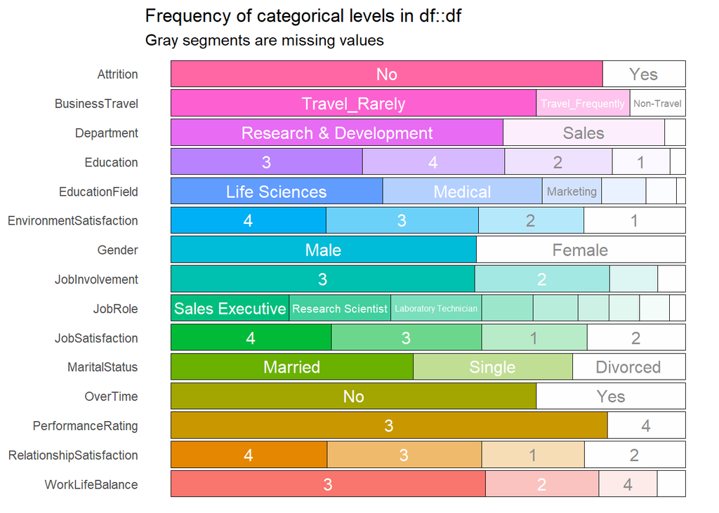

```r
# Inspect the categorical variables with a cool plot
show_plot(inspect_cat(df))
```

```r
# Plot function
cat_vs_cat_plot <- function(df, x,y){
  ggplot(data = df, aes_string(x = x, fill = y)) +
    geom_bar(position = "fill", alpha = 0.9) +
    coord_flip() +
    theme(legend.position="none",
          axis.title.x=element_blank(),
          axis.text.x=element_blank(),
          axis.ticks.x=element_blank(),
          plot.title = element_text(size = 5))
}

# Identify the names of the categorical variables
categorical_variables = df %>% select(-Attrition) %>% select_if(is.factor) %>% names()
categorical_variables
```

```
##  [1] "BusinessTravel"           "Department"
##  [3] "Education"                "EducationField"
##  [5] "EnvironmentSatisfaction"  "Gender"
##  [7] "JobInvolvement"           "JobRole"
##  [9] "JobSatisfaction"          "MaritalStatus"
## [11] "OverTime"                 "PerformanceRating"
## [13] "RelationshipSatisfaction" "WorkLifeBalance"
```

# Personal Categorical Metrics

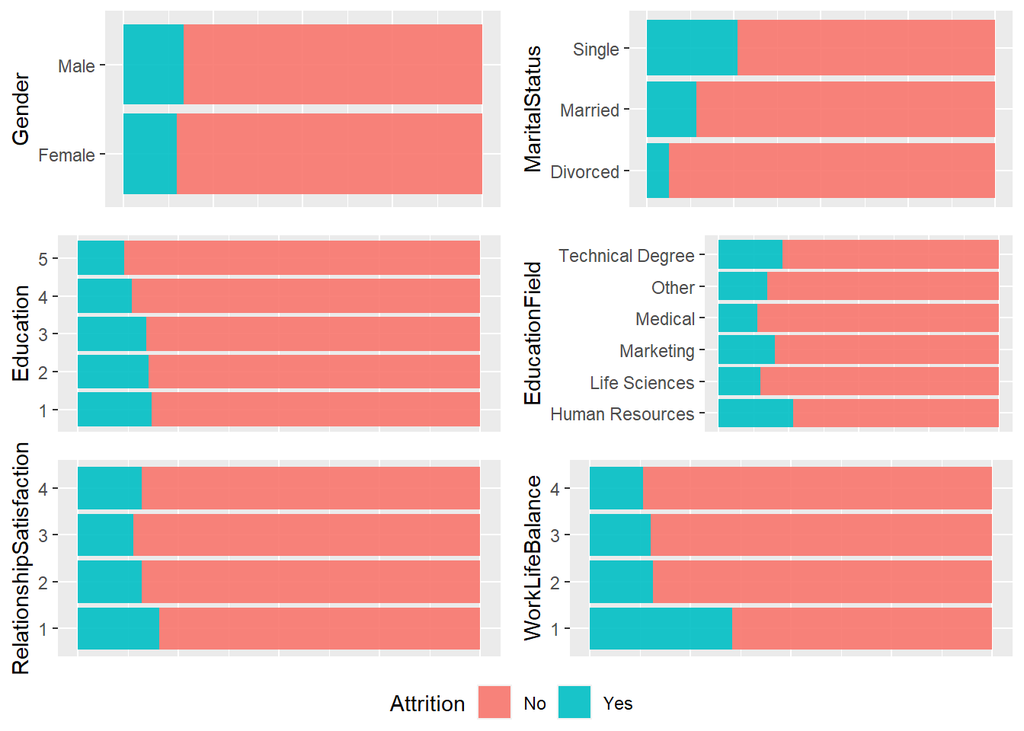

```r
personal_cat_plot_list <-lapply(categorical_variables[c(6, 10, 3, 4, 13, 14)],
                             function(x) cat_vs_cat_plot(df, x, "Attrition"))
ggarrange(plotlist = personal_cat_plot_list, common.legend = TRUE, legend="bottom",
          nrow = 3, ncol = 2)
```

Attrition:

1. Is slighty higher with male employees compared to female employees.
2. Is the highest for single people, and lowest for divorced people.
3. Decreases gradually as employees are more educated.
4. Is lowest amongst employees in the Medical and Life Sciences fields.
5. Has an extremely negative influence to an employee’s work life balance.

# Work Categorical Metrics

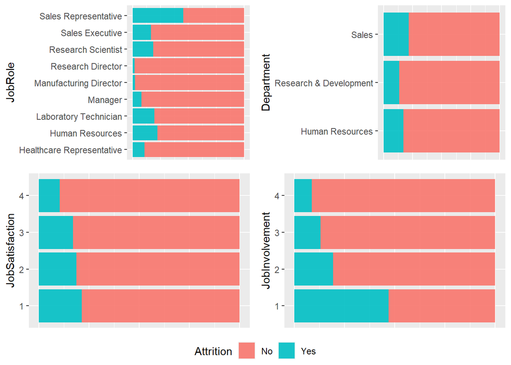

```r
work_cat_plot_list <-lapply(categorical_variables[c(8, 2, 9, 7)],
                             function(x) cat_vs_cat_plot(df, x, "Attrition"))
ggarrange(plotlist = work_cat_plot_list, common.legend = TRUE, legend="bottom",
          nrow = 2, ncol = 2)
```

Attrition:

1. Is highest with employees in Sales, and lowest in director/manager roles.
2. Has an extremely negative influence with an employee’s involvement with his/her job, and decreases gradually as she/he is more satisfied with their job.

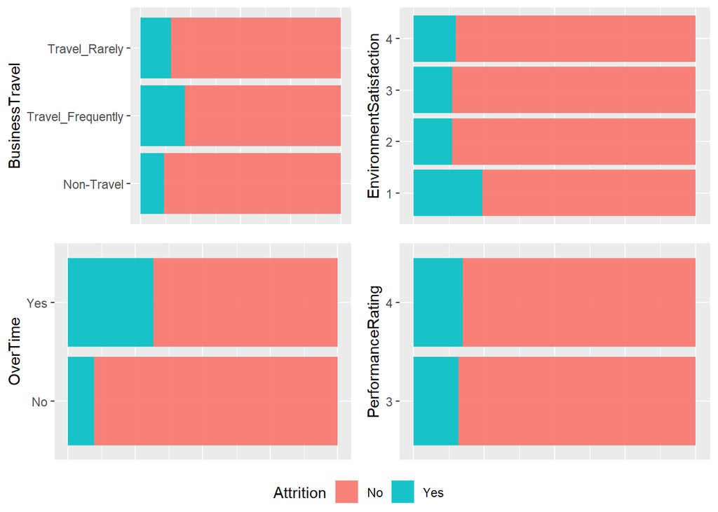

```r
work_cat_plot_list <-lapply(categorical_variables[c(1, 5, 11, 12)],
                             function(x) cat_vs_cat_plot(df, x, "Attrition"))
ggarrange(plotlist = work_cat_plot_list, common.legend = TRUE, legend="bottom",
          nrow = 2, ncol = 2)
```

Attrition:

1. Is highest with employees who travels frequently.
2. Has a highly negative influence with an employee’s work environment
3. Is high in overtime employees as expected.

# Numeric Variables: Visuallizing Correlations to Attrition

```r
numerical_variables_names = df %>% select_if(is.numeric) %>% names()
numerical_variables_names
```

```
##  [1] "Age"                     "DailyRate"
##  [3] "DistanceFromHome"        "HourlyRate"
##  [5] "JobLevel"                "MonthlyIncome"
##  [7] "MonthlyRate"             "NumCompaniesWorked"
##  [9] "PercentSalaryHike"       "StockOptionLevel"
## [11] "TotalWorkingYears"       "TrainingTimesLastYear"
## [13] "YearsAtCompany"          "YearsInCurrentRole"
## [15] "YearsSinceLastPromotion" "YearsWithCurrManager"
```

```r
p1 <- df %>% ggplot(aes(x = Age, fill = Attrition)) +
  geom_density(alpha = 0.5) +
  theme(axis.title.x=element_blank()) +
  ggtitle("Age")

p2 <- df %>% ggplot(aes(x = DailyRate, fill = Attrition)) +
  geom_density(alpha = 0.5) +
  theme(axis.title.x=element_blank()) +
  ggtitle("DailyRate")

p3 <- df %>% ggplot(aes(x = DistanceFromHome, fill = Attrition)) +
  geom_density(alpha = 0.5) +
  theme(axis.title.x=element_blank()) +
  ggtitle("DistanceFromHome")

p4 <- df %>% ggplot(aes(x = HourlyRate, fill = Attrition)) +
  geom_density(alpha = 0.5) +
  theme(axis.title.x=element_blank()) +
  ggtitle("HourlyRate")

p5 <- df %>% ggplot(aes(x = JobLevel, fill = Attrition)) +
  geom_density(alpha = 0.5) +
  theme(axis.title.x=element_blank()) +
  ggtitle("JobLevel")

p6 <- df %>% ggplot(aes(x = MonthlyIncome, fill = Attrition)) +
  geom_density(alpha = 0.5) +
  theme(axis.title.x=element_blank()) +
  ggtitle("MonthlyIncome")

p7 <- df %>% ggplot(aes(x = MonthlyRate, fill = Attrition)) +
  geom_density(alpha = 0.5) +
  theme(axis.title.x=element_blank()) +
  ggtitle("MonthlyRate")

p8 <- df %>% ggplot(aes(x = NumCompaniesWorked, fill = Attrition)) +
  geom_density(alpha = 0.5) +
  theme(axis.title.x=element_blank()) +
  ggtitle("NumCompaniesWorked")

p9 <- df %>% ggplot(aes(x = PercentSalaryHike, fill = Attrition)) +
  geom_density(alpha = 0.5) +
  theme(axis.title.x=element_blank()) +
  ggtitle("PercentSalaryHike")

p10 <- df %>% ggplot(aes(x = StockOptionLevel, fill = Attrition)) +
  geom_density(alpha = 0.5) +
  theme(axis.title.x=element_blank()) +
  ggtitle("StockOptionLevel")

p11 <- df %>% ggplot(aes(x = TotalWorkingYears, fill = Attrition)) +
  geom_density(alpha = 0.5) +
  theme(axis.title.x=element_blank()) +
  ggtitle("TotalWorkingYears")

p12 <- df %>% ggplot(aes(x = TrainingTimesLastYear, fill = Attrition)) +
  geom_density(alpha = 0.5) +
  theme(axis.title.x=element_blank()) +
  ggtitle("TrainingTimesLastYear")

p13 <- df %>% ggplot(aes(x = YearsAtCompany, fill = Attrition)) +
  geom_density(alpha = 0.5) +
  theme(axis.title.x=element_blank()) +
  ggtitle("YearsAtCompany")

p14 <- df %>% ggplot(aes(x = YearsInCurrentRole, fill = Attrition)) +
  geom_density(alpha = 0.5) +
  theme(axis.title.x=element_blank()) +
  ggtitle("YearsInCurrentRole")

p15 <- df %>% ggplot(aes(x = YearsSinceLastPromotion, fill = Attrition)) +
  geom_density(alpha = 0.5) +
  theme(axis.title.x=element_blank()) +
  ggtitle("YearsSinceLastPromotion")

p16 <- df %>% ggplot(aes(x = YearsWithCurrManager, fill = Attrition)) +
  geom_density(alpha = 0.5) +
  theme(axis.title.x=element_blank()) +
  ggtitle("YearsWithCurrManager")
```

# Personal Numerical Metrics

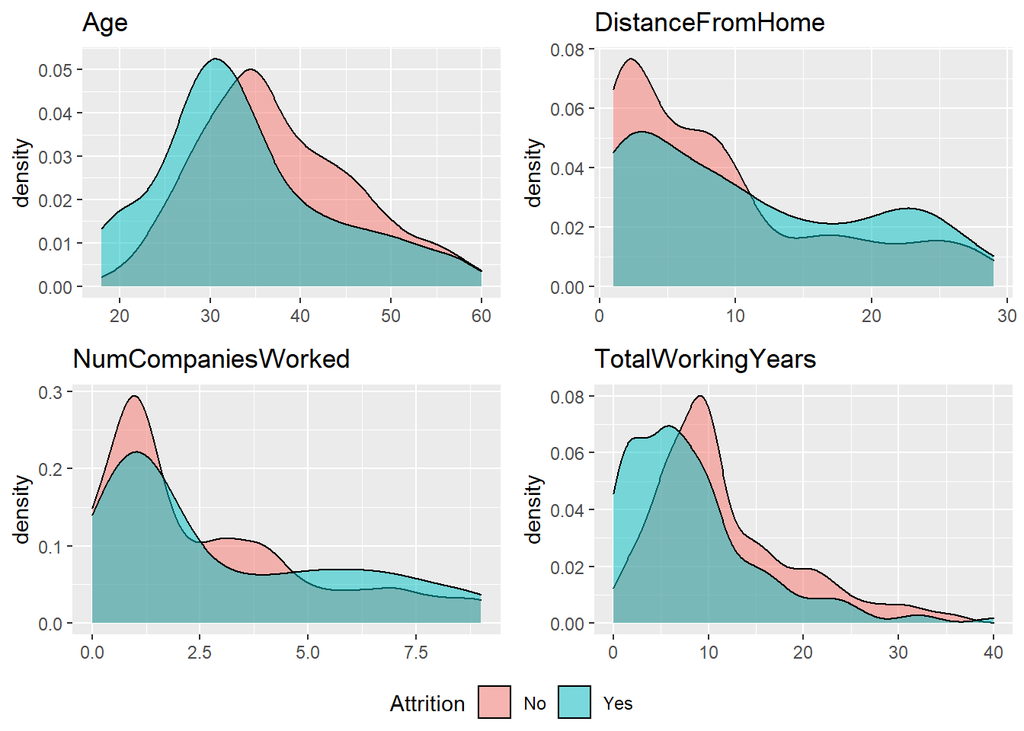

```r
ggarrange(p1, p3, p8, p11, nrow = 2, ncol = 2,
          common.legend = TRUE, legend="bottom")
```

# Compensation Numerical Metrics

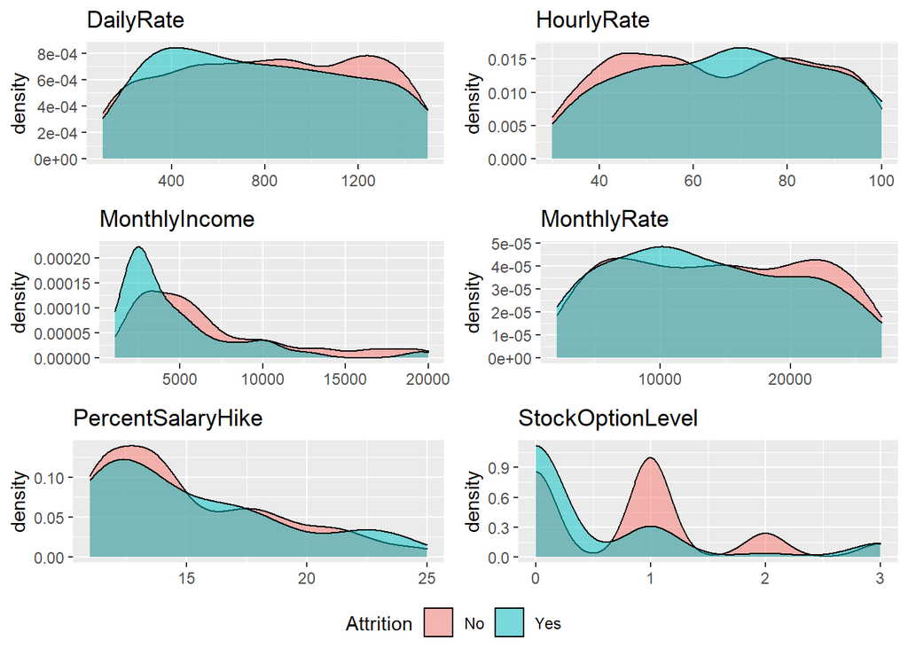

```r
ggarrange(p2, p4, p6, p7, p9, p10, nrow = 3, ncol = 2,
          common.legend = TRUE, legend="bottom")
```

Attrition:

1. Is extremely influential to a monthly income of around $2500.
2. Is extremely unlikely amongst employees with stock options.

# Work Numerical Metrics

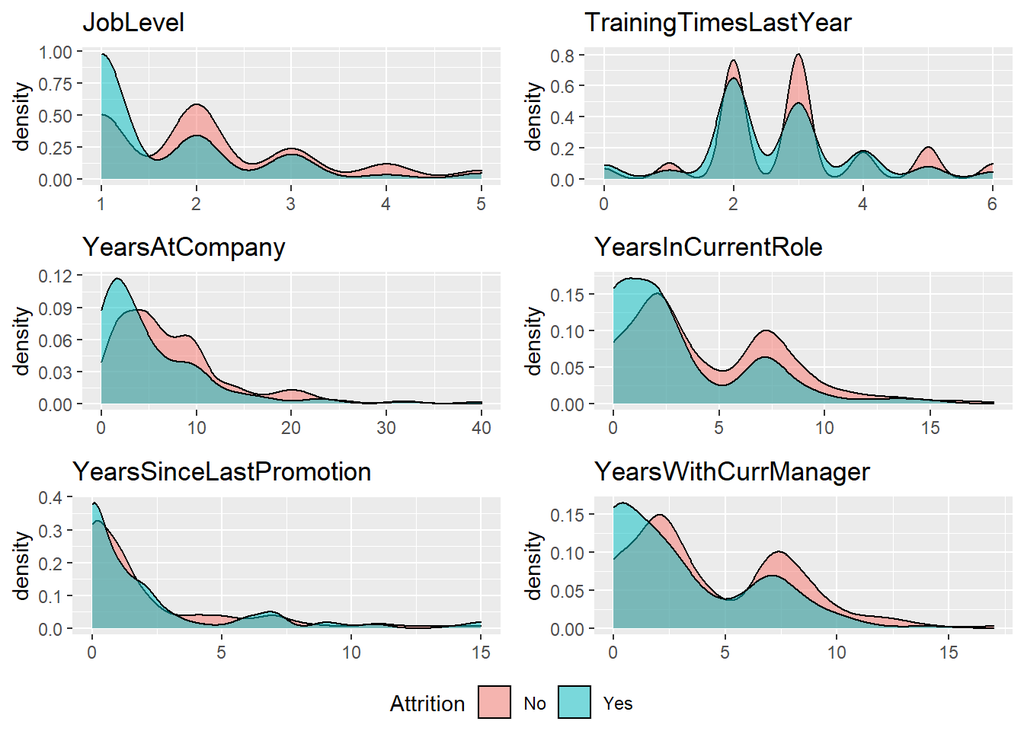

```r
ggarrange(p5, p12, p13, p14, p15, p16, nrow = 3, ncol = 2,
          common.legend = TRUE, legend="bottom")
```

Attrition:

1. Is extremely likely with 1st level employees, and gradually decreases as job level increases.
2. Is highest with employees of around 1 or 2 years in the company, as well as in their current role.
3. Has a noticeable gap between yes and no for all training times last year except for 4 times.

# Split The Data

70% of our data is used for training the model, and 30% is for testing the model and validate actual values vs predicted values.

```r
# Convert character variables into categorical variables
df = mutate_if(df, is.character, as.factor)

# Convert
df = mutate_if(df, is.integer, as.factor)

train_indices = createDataPartition(df$Attrition, p = 0.7, list = FALSE)
train = df[train_indices,]
test = df[-train_indices,]
```

# Predicting Attrition: KNN versus Naive Bayes

```r
dim(train)
```

```
## [1] 609  31
```

```r
# k-Nearest Neightbors (k-NN)
train_control = trainControl(method = "repeatedcv", number = 10, repeats = 3)
KNN_model = train(train[,model_formula],
                  as.factor(train$Attrition),
                  method = "knn",
                  trControl = train_control,
                  #preProcess = c("center","scale"),
                  tuneLength = 20)
KNN_CM = confusionMatrix(table(predict(KNN_model, train[,model_formula]),
                               as.factor(train$Attrition)))
```

```r
KNN_CM$overall["Accuracy"]
```

```
##  Accuracy
## 0.8456486
```

```r
KNN_CM$byClass["Sensitivity"]
```

```
## Sensitivity
##   0.9921722
```

```r
KNN_CM$byClass["Specificity"]
```

```
## Specificity
##  0.08163265
```

```r
# Naive Bayes
naiveBayes_model = naiveBayes(train[,model_formula],
                              as.factor(train$Attrition),
                              laplace = 1)
naiveBayes_CM = confusionMatrix(table(predict(naiveBayes_model, train[,model_formula]),
                                      as.factor(train$Attrition)))
```

```r
naiveBayes_CM$overall["Accuracy"]
```

```
##  Accuracy
## 0.9392447
```

```r
naiveBayes_CM$byClass["Sensitivity"]
```

```
## Sensitivity
##   0.9530333
```

```r
naiveBayes_CM$byClass["Specificity"]
```

```
## Specificity
##   0.8673469
```

```r
# Wrangling competition set
df_no_attrition = mutate_if(df_no_attrition, is.character, as.factor)
df_no_attrition = mutate_if(df_no_attrition, is.integer, as.factor)

df_no_attrition_predict <- predict(naiveBayes_model, df_no_attrition)

myout = cbind.data.frame(df_no_attrition$ID, df_no_attrition_predict)
colnames(myout) <- c("ID", "Attrition")
write.csv(myout, file ="Case2PredictionsNguyen Attrition.csv", row.names = FALSE)
```

Our Naive Bayes model represents the original data with 93.92% accuracy, 95.30% sensitivity, and 86.73% specificity, which is greater than the desired minimum of 60% sensitivity and specificity. We believe this model is among the best at classifying employee attrition at Fritolay.

It contains the following variables:

1. Age
2. DailyRate
3. Education
4. EnvironmentSatisfaction
5. JobInvolvement
6. JobLevel
7. JobSatisfaction
8. MonthlyIncome
9. MonthlyRate
10. RelationshipSatisfaction
11. StockOptionLevel
12. TotalWorkingYears
13. TrainingTimesLastYear
14. WorkLifeBalance
15. YearsAtCompany
16. YearsInCurrentRole
17. YearsWithCurrManager

# Predicting MonthlyIncome: Linear Regression

```r
train_indices = createDataPartition(attritionData$Attrition, p = 0.7, list = FALSE)

train = attritionData[train_indices,]
test = attritionData[-train_indices,]

# Linear Regression
fit = lm(formula = MonthlyIncome ~ Age + Education + JobLevel + MonthlyRate +
                   NumCompaniesWorked + TotalWorkingYears + YearsAtCompany +
                   YearsInCurrentRole + YearsSinceLastPromotion +
                   YearsWithCurrManager, data = train)
```

```r
summary(fit)$r.squared
```

```
## [1] 0.9114983
```

```r
predictions = predict(fit, test)
RMSE(test$MonthlyIncome, predictions)
```

```
## [1] 1432.709
```

```r
SalaryPred <- predict(fit, df_no_salary)
myout=cbind.data.frame(df_no_salary$ID,SalaryPred)
colnames(myout) = c("ID","MonthlyIncome")
write.csv(myout, file ="Case2PredictionsNguyen Salary.csv", row.names = FALSE)
```

Our linear regression model is 91.15% effective at representing the original data, with a prediction error of $1432.709 which is below our desired maximum of $3000.

It contains the following variables:

1. Age
2. Education
3. JobLevel
4. MonthlyRate
5. NumCompaniesWorked
6. TotalWorkingYears
7. YearsAtCompany
8. YearsInCurrentRole
9. YearsSinceLastPromotion
10. YearsWithCurrManager